# Администрирование системных подсистем

Настройка безопасного удалённого доступа по SSH

Сейдалиев Тагиетдин Ровшенович

Российский университет дружбы народов, Москва, Россия

05 декабря 2025

# Цель работы

## Основная цель

Приобрести практические навыки настройки защищённого SSH-доступа,  
включая работу с пользователями, ключевой аутентификацией, портами и туннелями.

# Запрет доступа root

## Попытка входа root

- Система запрашивает пароль, но не допускает root
- В журнале фиксируются отказанные попытки входа
- В конфигурации установлен `PermitRootLogin no`

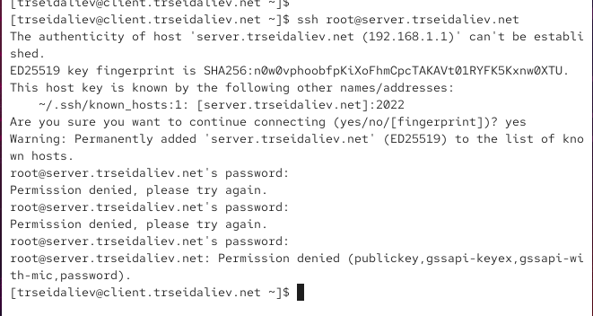

Попытка входа root

## Конфигурация

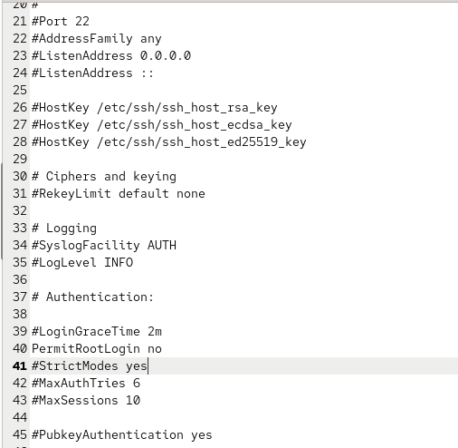

Конфигурация sshd root

После перезапуска службы результат остаётся тем же: вход root заблокирован.

# Ограничение пользователей SSH

## Вход пользователя trseidaliev

Успешное подключение:

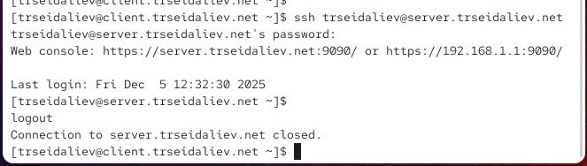

Успешный вход

## AllowUsers

Разрешён только `vagrant`:

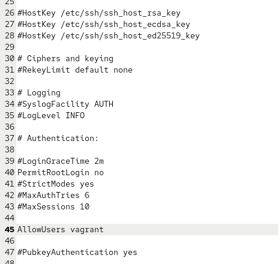

AllowUsers vagrant

Попытка входа trseidaliev завершается отказом:

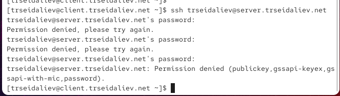

Отказ доступа

## Добавление второго пользователя

После добавления trseidaliev:

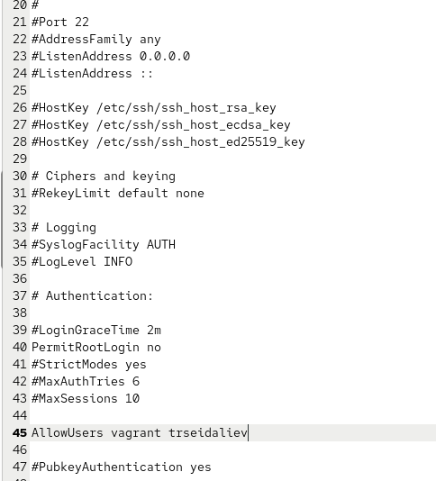

AllowUsers 2

Подключение снова доступно:

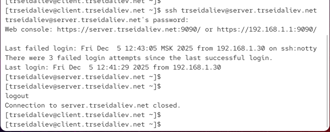

Успешный вход после изменения

# Настройка нескольких портов SSH

## Добавление порта 2022

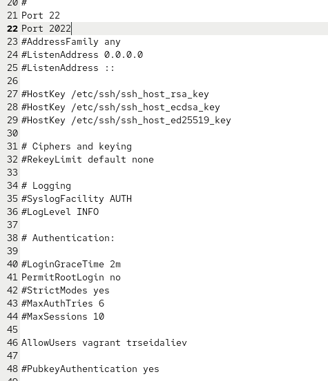

Добавление порта

## Ошибка SELinux

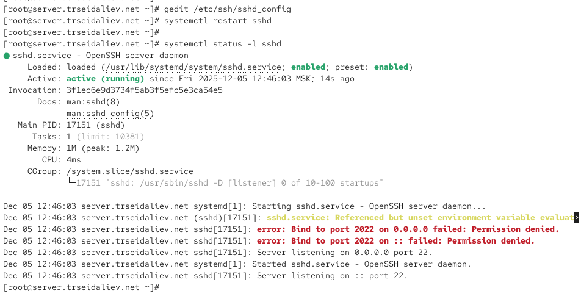

Permission denied port 2022

SELinux блокирует нестандартный порт до назначения корректной метки.

## Исправление и запуск

После настройки SELinux и firewall — оба порта работают:

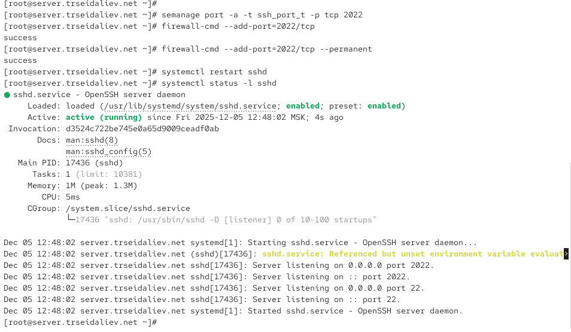

Порты 22 и 2022

## Проверка соединений

Через порт 22 и 2022:

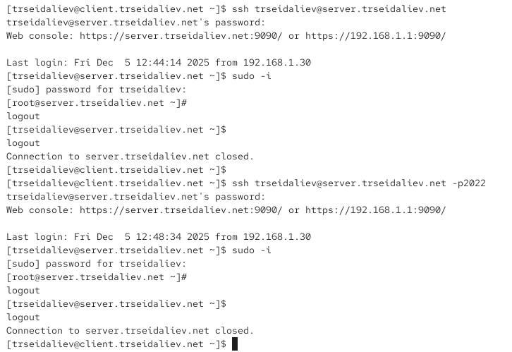

Подключение через 2022

# Подключение по ключам

## Включение PubkeyAuthentication

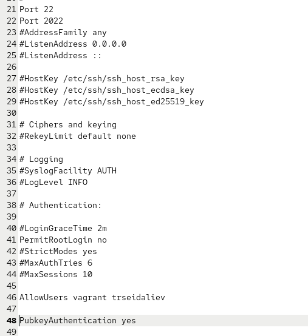

PubkeyAuth

## Установка ключей и подключение

Сгенерированы ключи, публичный импортирован на сервер.  
Подключение выполняется без пароля:

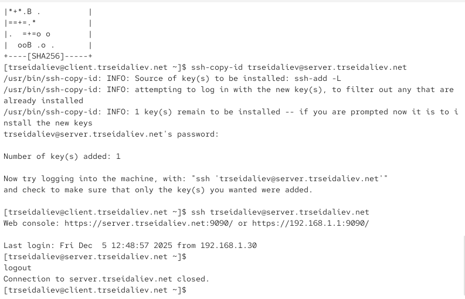

Успешное подключение по ключу

# SSH-туннели и перенаправление портов

## Создание туннеля

До туннеля — список соединений пуст.

После создания туннеля:

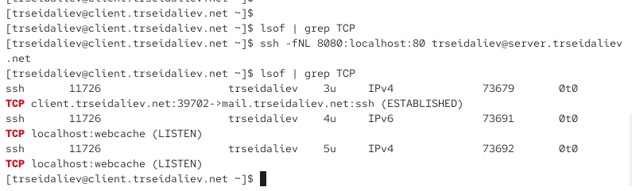

Список TCP

## Проверка

Переход на `localhost:8080` открывает страницу сервера:

[figure not shown]

Прокси веб-сервера

# Удалённый запуск приложений

## Консольные команды

hostname:

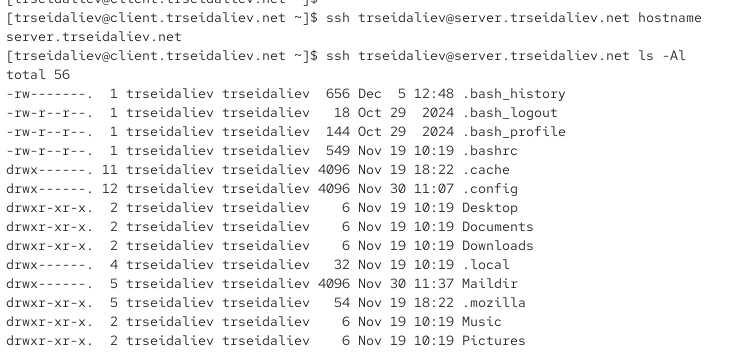

hostname

## Консольные команды

Maildir:

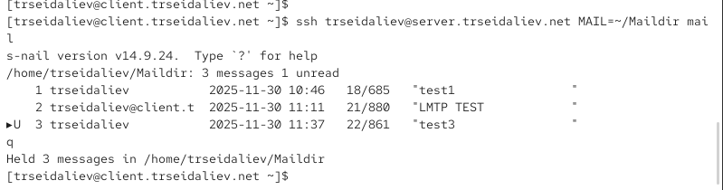

Maildir

# X11-переадресация

## Включение X11Forwarding

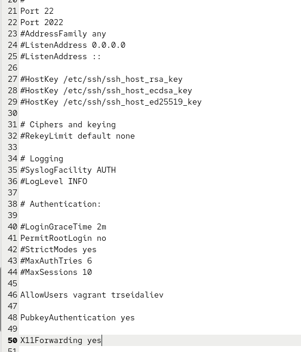

X11Forwarding

## Ошибка запуска GUI

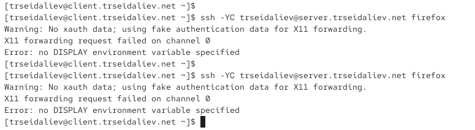

Ошибка X11

Причина: на клиенте отсутствует активный X-сервер.

# Автоматизация провижининга

## Создание каталога и скрипта

В каталог `/vagrant/provision/server/ssh/etc/ssh` помещён рабочий sshd_config.  
Файл `ssh.sh` автоматизирует все ручные действия.

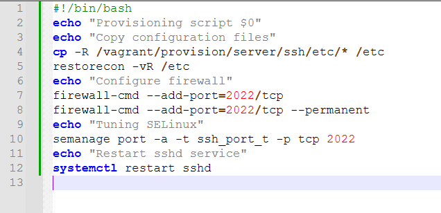

ssh.sh

# Итоги

## Основные результаты

- Ограничен список разрешённых пользователей
- Включена работа SSH на портах 22 и 2022
- Реализована аутентификация по ключам
- Созданы SSH-туннели и проверена их работа
- Выполнен удалённый запуск консольных приложений